# Homework Solutions

For MATH5001 by ctong

## Q1

##### **Q1. ACME’s CEO boasts that they have one of the highest paid sales force in the nation. He claims that average sales representative is paid over $28 per hour. Test this claim at a 10% level of significance.**

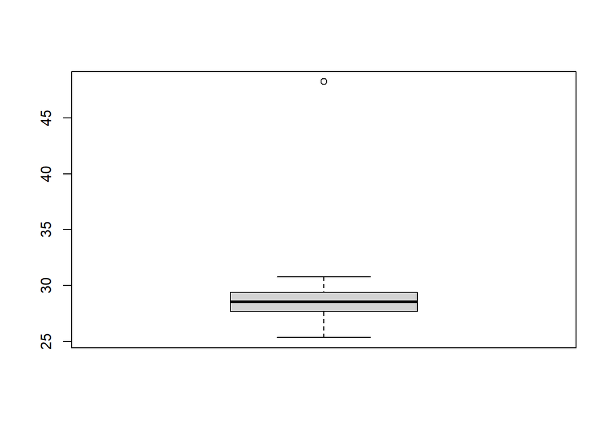

```r
df<-dfHR # create fresh copy of data frame

# Check for outliers
hpOut<-boxplot(df$HrPay)$out
```

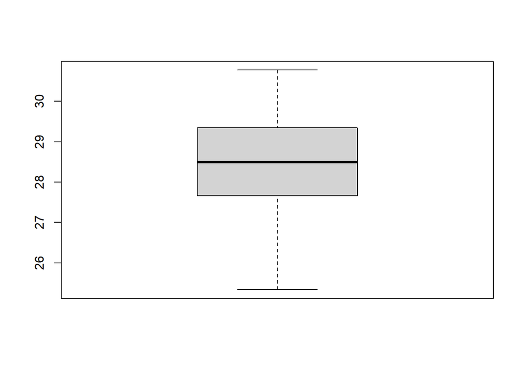

```r
# Remove outliers
df2<-df[!(df$HrPay %in% hpOut),]

# Recheck outliers
boxplot(df2$HrPay)
```

```r
# Test for normality
shapiro.test(df2$HrPay)
```

```
##
##  Shapiro-Wilk normality test
##
## data:  df2$HrPay
## W = 0.98675, p-value = 0.2987
```

```r
# p-value from Shapiro-test > .05, normality assumption met

# Descriptive statistics
describe(df2$HrPay)
```

```
##    vars   n  mean   sd median trimmed  mad   min   max range  skew kurtosis
## X1    1 119 28.46 1.17  28.49    28.5 1.25 25.34 30.77  5.43 -0.31    -0.34
##      se
## X1 0.11
```

```r
# Normality assumption is met

# Perform 1-tailed t-test for mean
t.test(df2$HrPay,mu=28, alternative="greater")
```

```
##
##  One Sample t-test
##
## data:  df2$HrPay
## t = 4.2726, df = 118, p-value = 1.967e-05
## alternative hypothesis: true mean is greater than 28
## 95 percent confidence interval:
##  28.27956      Inf
## sample estimates:
## mean of x
##  28.45681
```

**Results:** *t*(118) = 4.27, *p* < .01.

*p* is less than $\alpha$ of .10.

$\therefore$ We can conclude that the average sales representative is paid over $28 per hour at 10% level of significance.

## Q2

##### **Q2. An internal HR report indicated that the sales representatives at ACME publishing claimed less than $3000 in benefits in the current year. Does the sample data support this claim?**

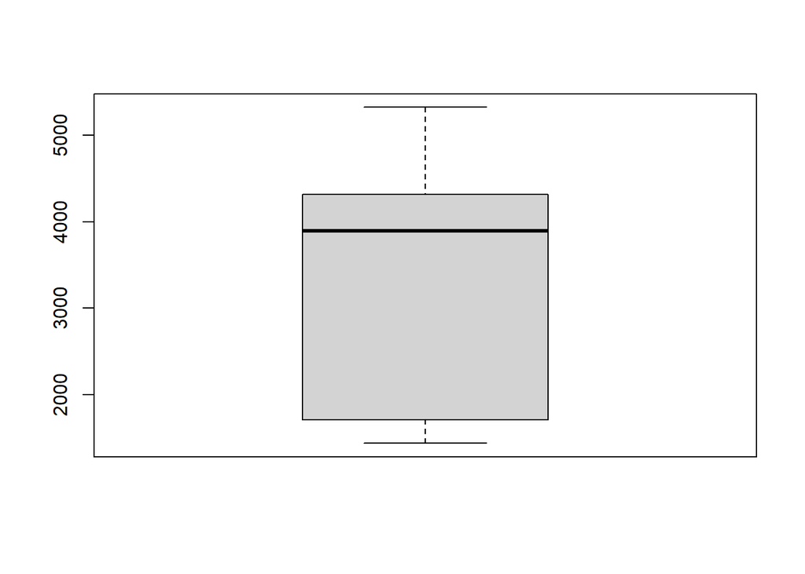

```r
df<-dfHR #create fresh copy of data frame

# Check for outliers
ppOut<-boxplot(df$BeneCurr)$out
```

```r
# No outliers

# Check for normality
shapiro.test(df$BeneCurr)
```

```
##
##  Shapiro-Wilk normality test
##
## data:  df$BeneCurr
## W = 0.83864, p-value = 4.009e-10
```

```r
# p-value for shapiro test < .05, normality assumption violated

# Descriptive statistics
describe(df$BeneCurr)
```

```
##    vars   n    mean      sd median trimmed     mad  min  max range  skew
## X1    1 120 3615.23 1329.41   3894 3672.22 1167.55 1438 5322  3884 -0.52
##    kurtosis     se
## X1    -1.04 121.36
```

```r
# Normality assumption was violated

# Perform 1-tailed 1-S wilcoxon signed-rank test for mean instead of t-test
wilcox.test(df$BeneCurr, mu = 3000, alternative="less")
```

```
##
##  Wilcoxon signed rank test with continuity correction
##
## data:  df$BeneCurr
## V = 4910, p-value = 0.9996
## alternative hypothesis: true location is less than 3000
```

**Results:** *p* > .99.

*p* is greater than $\alpha$ of .05.

$\therefore$ We can not conclude that on average, a sales representative claimed less than $3000 in benefits in the current year.

## Q3

##### **Q3. In a recent company memo at ACME publishing, sales representatives were congratulated for their exceptional performance. The memo reported that over 10% of the sales representatives were awarded a bonus. Verify this claim using the sample data provided.**

```r
df<-dfHR #create fresh copy of data frame

# Count number of reps who received each type of action: mentor | none | bonus
actionCounts<-table(df$Action)

n = sum(actionCounts)  # sample size
n
```

```
## [1] 120
```

```r
# Assign number of successes (i.e., Bonus) to x
x = actionCounts["Bonus"]
x
```

```
## Bonus
##    13
```

```r
# All assumptions met:sample size > 50, success and failure both > 5

# Perform 1-tailed test
prop.test(x,n,p=.1, alternative = "greater", correct=FALSE)
```

```
##
##  1-sample proportions test without continuity correction
##
## data:  x out of n, null probability 0.1
## X-squared = 0.092593, df = 1, p-value = 0.3805
## alternative hypothesis: true p is greater than 0.1
## 95 percent confidence interval:
##  0.07001757 1.00000000
## sample estimates:
##         p
## 0.1083333
```

**Results:** $\chi^2$(1) = 0.09, *p* = .38.

*p* > .05, therefore we cannot conclude that over 10% of sales reps were awarded a bonus.

## Q4

##### **Q4. One of the sales managers at ACME publishing believes that employees who received a bonus are unlikely to miss professional development workshops. She believes that among those who received a bonus, less than half missed the workshop. Does the sample data support this belief at an alpha level of .10?**

```r
df<-subset(dfHR, dfHR$Action=="Bonus") # create data frame for only reps who received bonus

# count number of reps who attended workshop and number who did not
pdCounts<-table(df$ProfDev)


n = sum(pdCounts)
n  # sample size < 50, use binom test
```

```
## [1] 13
```

```r
# Assign number who missed workshop to x
x = pdCounts["No"]
x
```

```
## No
##  7
```

```r
# Perform 1-tailed binomial test
binom.test(x,n,p=.5, alternative = "less")
```

```
##
##  Exact binomial test
##
## data:  x and n
## number of successes = 7, number of trials = 13, p-value = 0.7095
## alternative hypothesis: true probability of success is less than 0.5
## 95 percent confidence interval:
##  0.0000000 0.7760446
## sample estimates:
## probability of success
##              0.5384615
```

**Results:** *p* = .71.

Question specified $\alpha$ of .10.

*p* > .10, therefore we cannot conclude that less than 50% of all sales reps who received a bonus missed the workshop at a .10 level of significance.

## Q5

##### **Q5. An internal HR report claimed that last year’s performance ratings had an mean score of 7. Verify this claim using the sample data provided.**

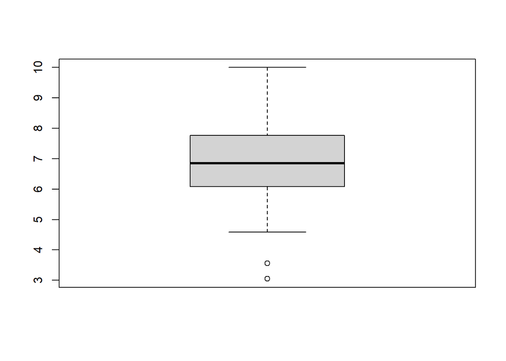

```r
df<-dfHR # Create fresh copy of data frame

# Check for outliers
ppOut<-boxplot(df$PerfPrev)$out
```

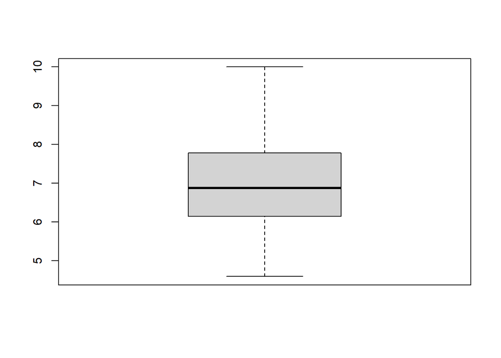

```r
# 2 outliers identified, remove outliers
df2<-df[!(df$PerfPrev %in% ppOut),]

# Re-check for outliers
boxplot(df2$PerfPrev)
```

```r
# Test normality
shapiro.test(df2$PerfPrev)
```

```
##
##  Shapiro-Wilk normality test
##
## data:  df2$PerfPrev
## W = 0.98918, p-value = 0.4766
```

```r
# Normality assumption is met

# Descriptive statistics
describe(df2$PerfPrev)
```

```
##    vars   n mean   sd median trimmed  mad  min max range skew kurtosis   se
## X1    1 118 6.99 1.22   6.87    6.96 1.25 4.59  10  5.41 0.21    -0.42 0.11
```

```r
# Perform 2-tailed test
t.test(df2$PerfPrev, mu = 7, alternative="two.sided")
```

```
##
##  One Sample t-test
##
## data:  df2$PerfPrev
## t = -0.065711, df = 117, p-value = 0.9477
## alternative hypothesis: true mean is not equal to 7
## 95 percent confidence interval:
##  6.770417 7.214837
## sample estimates:
## mean of x
##  6.992627
```

**Results:** *t*(117) = -0.07, *p* = .95.

*p* > .05, so we can not conclude that last year’s performance ratings deviated significantly from a mean score of 7 at an $\alpha$ of .05. This is consistent with the original claim.